# Assignment-3

LEVIN_S

2023-09-12

1. In this problem, you will develop a model to predict whether a given car gets high or low gas mileage based on the Auto data set.

```r
library(ISLR)
summary(Auto)
```

```
##       mpg          cylinders      displacement     horsepower        weight
##  Min.   : 9.00   Min.   :3.000   Min.   : 68.0   Min.   : 46.0   Min.   :1613
##  1st Qu.:17.00   1st Qu.:4.000   1st Qu.:105.0   1st Qu.: 75.0   1st Qu.:2225
##  Median :22.75   Median :4.000   Median :151.0   Median : 93.5   Median :2804
##  Mean   :23.45   Mean   :5.472   Mean   :194.4   Mean   :104.5   Mean   :2978
##  3rd Qu.:29.00   3rd Qu.:8.000   3rd Qu.:275.8   3rd Qu.:126.0   3rd Qu.:3615
##  Max.   :46.60   Max.   :8.000   Max.   :455.0   Max.   :230.0   Max.   :5140
##
##   acceleration        year           origin                      name
##  Min.   : 8.00   Min.   :70.00   Min.   :1.000   amc matador       :  5
##  1st Qu.:13.78   1st Qu.:73.00   1st Qu.:1.000   ford pinto        :  5
##  Median :15.50   Median :76.00   Median :1.000   toyota corolla    :  5
##  Mean   :15.54   Mean   :75.98   Mean   :1.577   amc gremlin       :  4
##  3rd Qu.:17.02   3rd Qu.:79.00   3rd Qu.:2.000   amc hornet        :  4
##  Max.   :24.80   Max.   :82.00   Max.   :3.000   chevrolet chevette:  4
##                                                  (Other)           :365
```

1. Create a binary variable, mpg01, that contains a 1 if mpg contains a value above its median, and a 0 if mpg contains a value below its median. You can compute the median using the median() function. Note you may find it helpful to use the data.frame() function to create a single data set containing both mpg01 and the other Auto variables.

```r
attach(Auto)
```

```r
mpg01 <- ifelse( mpg > median(mpg), yes = 1, no = 0)
```

```r
Auto_1 <- data.frame(Auto, mpg01)

View(Auto_1)
```

2. Explore the data graphically in order to investigate the association between mpg01 and the other features. Which of the other features seem most likely to be useful in predicting mpg01? Scatterplots and boxplots may be useful tools to answer this question. Describe your findings.

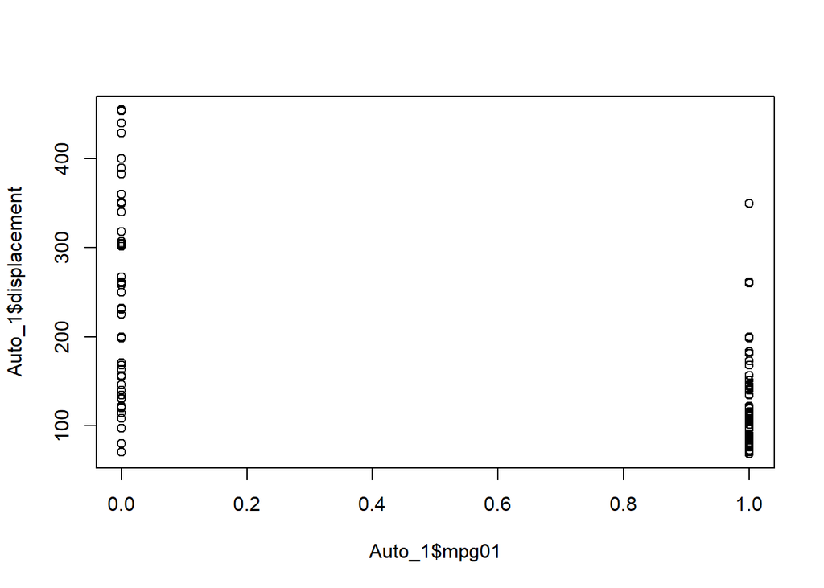

```r
plot(Auto_1$mpg01,Auto_1$displacement)
```

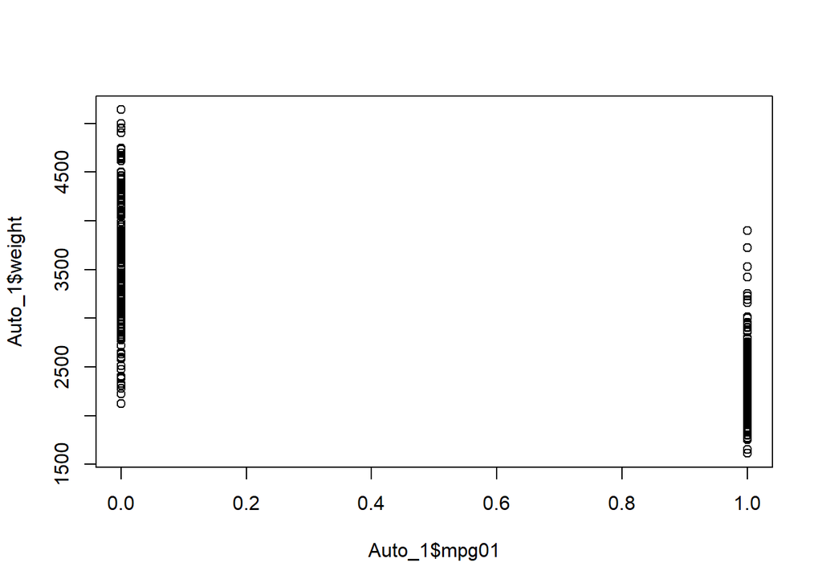

```r
plot(Auto_1$mpg01,Auto_1$weight)
```

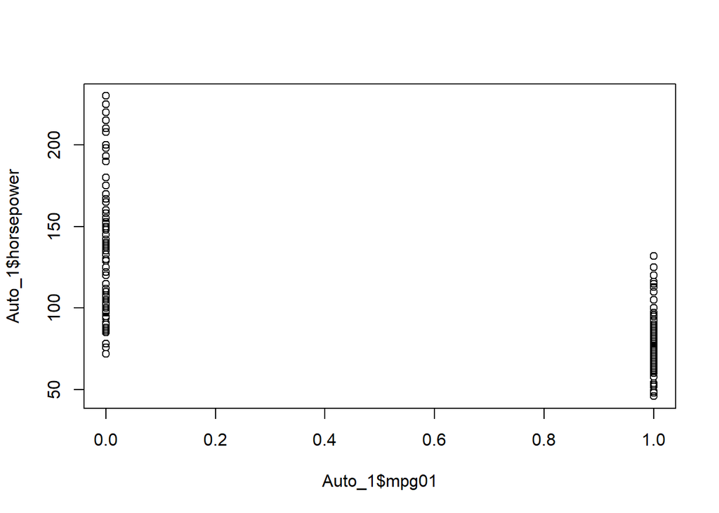

```r
plot(Auto_1$mpg01,Auto_1$horsepower)
```

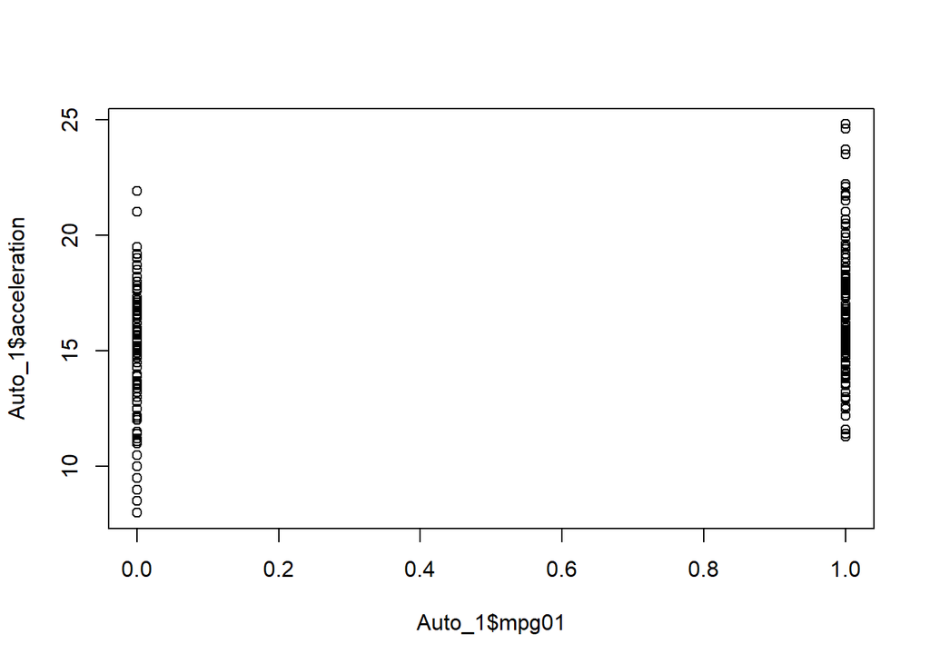

```r
plot(Auto_1$mpg01,Auto_1$acceleration)
```

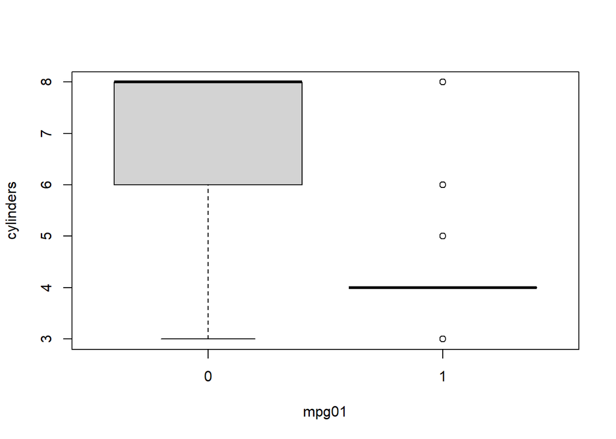

```r
boxplot(cylinders~mpg01)
```

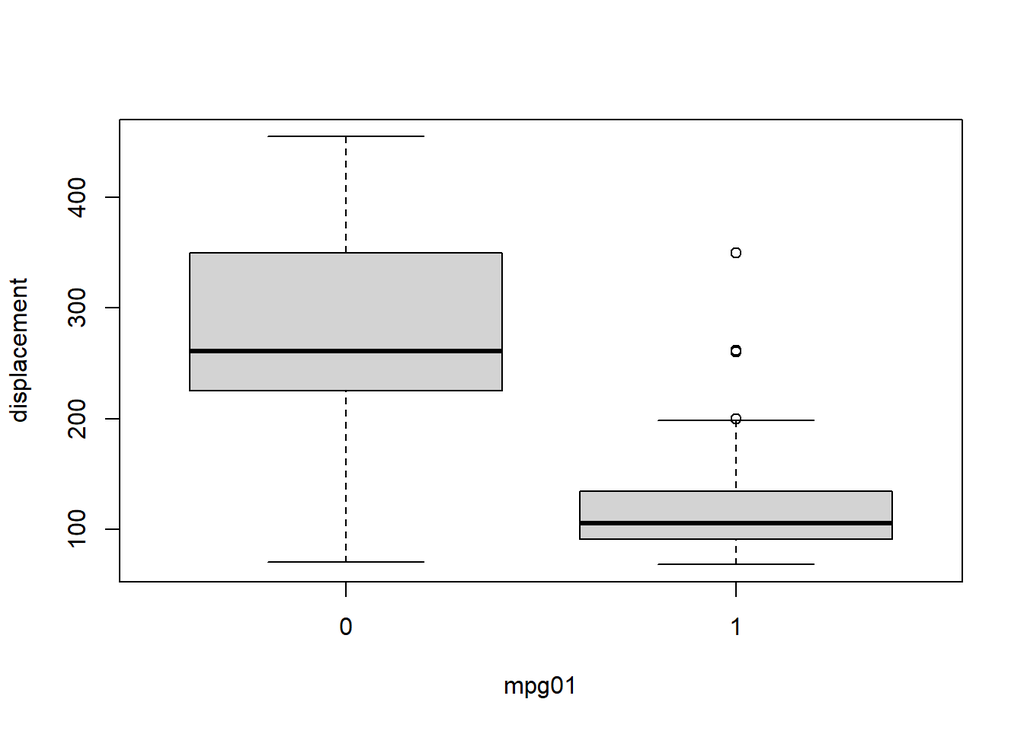

```r
boxplot(displacement~mpg01)
```

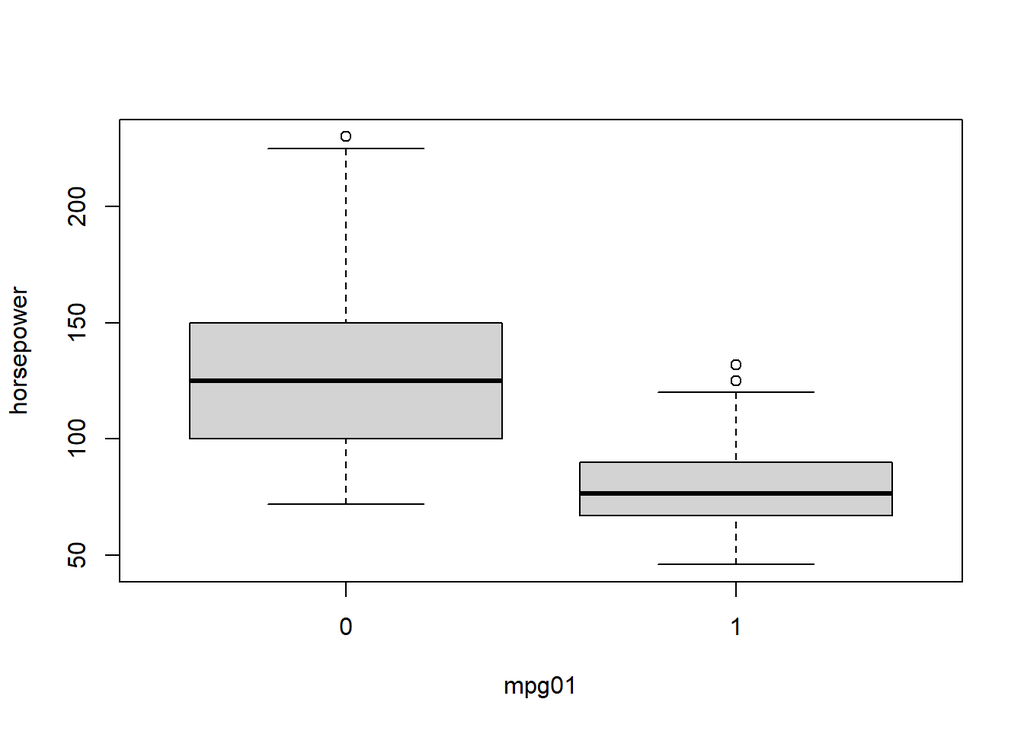

```r
boxplot(horsepower~mpg01)
```

```r
train<-sample(nrow(Auto_1), size = nrow(Auto_1)*0.70)
train_data=Auto_1[train,]
test_data=Auto_1[-train,]

dim(Auto_1)
```

```
## [1] 392  10
```

```r
dim(test_data)
```

```
## [1] 118  10
```

```r
dim(train_data)
```

```
## [1] 274  10
```

```r
library(MASS)
```

```r
lda_model<- lda(mpg01~displacement+weight+acceleration+horsepower+cylinders, data=train_data)
lda_pred<- predict(lda_model,test_data)
lda_error <- mean(lda_pred$class != test_data$mpg01)
```

```r
qda_model <- qda(mpg01 ~ displacement+weight+acceleration+horsepower+cylinders, data=train_data)
qda_pred <- predict(qda_model, test_data)
qda_error <- mean(qda_pred$class != test_data$mpg01)
```

```r
logistic_model <- glm(mpg01 ~ displacement + weight + acceleration + horsepower + cylinders, data = train_data, family = binomial)

logistic_pred <- predict(logistic_model, newdata = test_data, type = "response")

logistic_pred_binary <- ifelse(logistic_pred > 0.5, 1, 0)

logistic_error <- mean(logistic_pred_binary != test_data$mpg01)
```

7. Perform KNN on the training data, with several values of K, in order to predict mpg01. Use only the variables that seemed most associated with mpg01 in (b). What test errors do you obtain? Which value of K seems to perform the best on this data set?

```r
train_data <- na.omit(train_data)
```

```r
library(class)

k_values <- c(1, 3, 5, 7)

knn_errors <- numeric(length(k_values))

for (i in 1:length(k_values)) {
  knn_pred <- knn(train = train_data[, c("displacement", "weight", "acceleration", "horsepower", "cylinders")],
                   test = test_data[, c("displacement", "weight", "acceleration", "horsepower", "cylinders")],
                   cl = train_data$mpg01, k = k_values[i])
  knn_errors[i] <- mean(knn_pred != test_data$mpg01)
}

best_k <- k_values[which.min(knn_errors)]
best_k_error <- min(knn_errors)
```

```r
best_k
```

```
## [1] 3
```

```r
best_k_error
```

```
## [1] 0.1186441
```